# Federal Housing Spending and Homelessness Rates Across U.S. CoCs

By: Caroline, Mercedes, Shukra, & Yahya

2025-06-04

```r
library(tidyverse)
library(openintro)
```

### Abstract

This project examines the relationship between federal housing funding and homelessness rates across U.S. Continuums of Care (CoCs) using 2024 data from HUD, the Urban Institute, and the American Community Survey. Through principal component analysis (PCA) and linear regression, we found that structural and demographic variables, particularly urbanization, racial diversity, and housing strain, were stronger predictors of where funding goes (adjusted R² = 54%) than of actual homelessness rates (adjusted R² = 33%). Visual analyses revealed that Black, American Indian/Alaska Native, and Native Hawaiian/Pacific Islander populations are consistently overrepresented in homeless populations, though no clear evidence showed unequal funding by race. Importantly, some affluent CoCs received more funding despite lower homelessness, while rural or economically disadvantaged areas with lower visibility received less, indicating a disconnect between funding allocation and actual need. These results suggest current funding strategies may reinforce existing disparities, highlighting the need for more equitable and data-sensitive policy approaches.

### Introduction

Homelessness and housing affordability are increasingly urgent issues in the United States, impacting individuals, communities, and broader social systems. In response, the federal government has allocated substantial funding to support homelessness prevention and housing programs through local Continuums of Care (CoCs). This project investigates the relationship between federal housing funding and rates of homelessness across various CoCs using data from the U.S. Department of Housing and Urban Development’s 2024 Annual Homelessness Assessment Report (AHAR). The primary objective of this analysis is to evaluate whether higher levels of federal funding are associated with lower rates of homelessness. In addition, the study explores disparities in homelessness outcomes by racial group to assess whether funding is equitably distributed and effective across demographic subpopulations. Understanding the impact of federal investments is critical for informing future housing policy and resource allocation. The findings of this analysis are presented in the results section.

The data that was used for this project and analysis came from multiple sources. We started with data from the Urban Institute (UI) which includes a significant amount of data related to federal funded programs. UI collected funding information on all major IIJA and HUB programs from official websites and media announcements from various departments and agencies that administer these programs. There were a few criteria that UI used during the data collection. The major programs in HUD were defined as those who distributed at least $1 billion in the fiscal years 2022 or at least $1 billion from 2022-2026 for IIJA. There were a total of 66 programs that met UI criteria and were included in the data. Within these 66 programs, jurisdictions needed to be identified, and lists needed to be compiled for every federal funded project in the fiscal years 2022. This was done using departmental press releases and supplemental research.

The data containing information about homelessness counts across CoC boundaries was taken from the U.S. Department of Housing and Urban Development’s (HUD) 2024 Annual Homelessness Assessment Report (AHAR) to Congress, Part 1. The report is premised on data collected from the annual Point-in-Time (PIT) count made nationwide, approximating the homeless individuals on a single evening in January of every year. PIT count includes individuals living in emergency shelters, transitional housing, or safe havens, and living in unsheltered locations not intended for human habitation, such as streets, parks, and cars. Local Continuums of Care (CoCs), which are local planning organizations that are responsible for coordinating homelessness service delivery, administered the data through HUD-approved methods, including direct interviews and observational surveys. In addition to the PIT count, the Housing Inventory Count (HIC) was conducted to quantify the availability of shelter and housing resources. Together, these measures provide an accurate snapshot of homelessness across the United States, both the magnitude of the issue and community capacity to address it.

### Methods

#### Merging Data:

The research process began with an initial exploration of a dataset on federal infrastructure funding from 2022 to 2023 provided by the Urban Institute. This was done in order to understand its structure, variables, and the gaps that would need to be filled by external data sources. We chose to focus on two tables from this source: county indicators and country programs, which included information about federally funded infrastructure programs and community demographic data for county levels. There was some exploration done with the state data, but as there were only 52 observations, which was not enough to make a model. There was a significant amount of cleaning, restructuring, and merging that needed to be completed in order to build a dataset sufficient with the information necessary to answer the research question. There were many federally funded infrastructure programs in the initial data, but for the sake of answering our question, we kept the data related to housing programs only. We also kept about half of the indicator variables based on relevancy to housing, demographics, and job-related transit. We supplemented UI’s data set with a more detailed breakdown of race and age demographics with a data set from the American Community Survey (ACS).

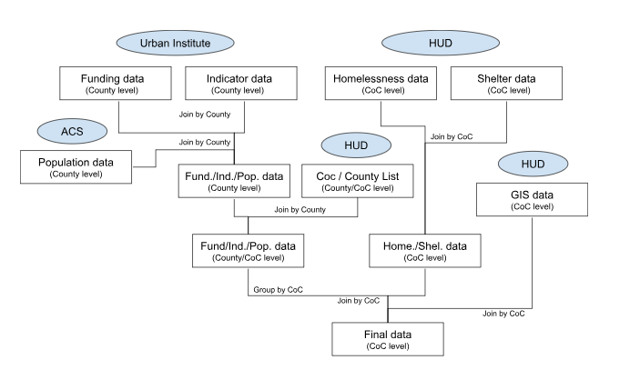

Data Source Diagram

#### Variables and EDA

Our variables of interest in our data exploration were homeless rate(%) and federal housing funding (dollars per capita). The initial exploratory data analysis examined a multitude of components within the data in order to determine any significant relationships between the other variables and the dependent variable. These relationships were examined in order to find ones which may be helpful predictors in a principal component analysis (PCA) and linear model using those new principal components. We first examined homeless rate and funding per capita on maps of the continental United States. Next, the relationship between homeless rate and funding per person were visualized using a scatterplot. This visualization prompted the exploration of many other variables that could be useful predictors for federal funding for housing per person such as racial demographics, social variables like overcrowded housing and age demographics of the population, and economic variables like median household income and the poverty rate of each CoC. The racial demographics for the homeless populations were visualized using maps. Additionally, density plots and bar plots were used to visualize any disparity between the proportion of each group in the homeless population versus the overall population. The racial groups included in our data were the same as those used by the United States Census Bureau; American Indian/Alaska Native, Asian, Native Hawaiian or Other Pacific Islander, Black, Multi, and White. The other social and economic variables that we investigated were also visualized on scatterplots and maps.

#### Principal Component Analysis

We chose to perform a principal component analysis on our selected predictor variables because previous experimentation with linear regression suggested that many of our independent variables were collinear. The goal for this analysis was to be able to predict funding per person and homelessness rates. These two variables were excluded from being a part of any of the components. The data were standardized by setting the mean to 0, and each observation was replaced with its z-score. The variables that were included for the principal components analysis were: median household income (med_hh_income), percentage of people of color (percent_poc), percentage of Hispanic and Latin American (pop_hisp_latx), percentage of the population that is under the age of 18 (pop_under_18), percentage of the population that is over the age of 64 (pop_over_64), population density (pop_density), employment access index (employment_access_index), poverty rate (poverty_rate), share of population who pays ≥ 30% of their income to housing (housing_cost_burden), share of homes with an average of 2 or more people per room (overcrowded_housing), and housing units per capita (housing_units).

These variables were chosen based on their reliability as economic and demographic indicators for each CoC. Some nuance was lost including the variable percent_poc instead of rates for every race, but the loadings were too difficult to read when so many of the groups account for such a small share in the population that a relatively minor difference accounted for a massive shift in the principal components. Leaving the smaller racial groups out in favor of percent_poc allowed us to reduce the complexity of interpreting the loadings for each principal component, but this also comes at the cost of potentially missing valuable patterns related to homelessness and federal funding moderated by those smaller groups. We also elected not to include every age group in our PCA. Instead, we kept pop_under_18 and pop_over_64, but left out the age groups in the middle, assuming that the majority of them would have jobs and that the information contained in the other age groups could still be inferred from examining the “age bookends.”

### Results

#### PCA Results

To better understand the underlying structure of the data and reduce dimensionality, we conducted a principal component analysis (PCA). This method allowed us to identify patterns in the dataset by transforming the original variables into a smaller set of uncorrelated components that explain the most variance. The results of the PCA highlight which variables contribute most strongly to the principal components and provide insights into groupings or trends within the data.

The first principal component (PC1) appears to capture a contrast between urban, racially diverse areas and more suburban or rural, predominantly white areas with greater housing availability. High PC1 scores are associated with higher proportions of people of color and Latinx residents, elevated housing cost burdens, and lower per capita housing units suggesting urban density and housing strain. Conversely, low PC1 scores represent regions with more housing, whiter populations, and younger demographics.

The second component (PC2) reflects an economic gradient. CoCs with high PC2 scores tend to have higher median household incomes, more children, and lower poverty rates. In contrast, low PC2 scores indicate greater economic disadvantage, with fewer children and higher poverty and housing cost burdens. This dimension helps distinguish more affluent CoCs from those facing greater structural poverty.

The third component (PC3) differentiates CoCs by population density, age structure, and housing access. High PC3 scores are associated with lower density areas that have larger youth populations and weaker employment access. Low scores represent dense, older communities with more established infrastructure and better economic access.

The fourth component (PC4) contrasts older, rural CoCs with wealthier, Latinx populations against dense, impoverished urban areas. High scores represent aging populations with higher household income and lower poverty, while low scores indicate communities with greater density, housing cost burden, and poverty.

The fifth component (PC5) appears to capture a housing quality and crowding dimension. High PC5 scores are associated with high housing cost burdens but low overcrowding which are indicative of suburban or middle-income areas where housing is expensive but less cramped. Low PC5 scores point to areas with both high cost burdens and high overcrowding, suggesting acute housing pressure and affordability crisis.

### Discussion

While there is a clear disparity in the homeless population compared to the overall population for many races, there was no data included in this analysis to indicate that one or more of these groups experienced disparity in receiving federal funding for housing. However when the variable percent_poc was used as a significant part of a component for the PCA, it was a positive predictor for both models, indicating that CoC’s with more racial diversity than others received additional funding per person, but were also more likely to have a higher homeless rate. This disparity was investigated and researched. Oftentimes funds are allocated based on surveys of communities to determine if there is a need for additional housing funding from federal institutions. According to a housing study done by Kithulgoda et al, the VI-SPDAT, a tool that is used to determine access to homelessness services and housing, leads to a significant amount of under-reporting for mental illness or incarcerations especially in Black individuals (Racial and gender bias in self-reported needs when using a homelessness triaging tool, pg. 4). The authors argue that solely relying on tools like this may unintentionally reinforce racial and gender inequalities and could be a reason for why minority groups struggle to escape homelessness. Components tied to urbanization, racial diversity, and housing strain (PC1) were significant positive predictors in both models, indicating that more urban and housing-burdened CoCs both receive more funding and experience higher homelessness. However, PC2, representing economic advantage, was positively associated with funding but had no significant effect on homelessness rates, highlighting a potential mismatch as more affluent CoCs may be better positioned to secure funding regardless of actual need. Conversely, PC3, which captures rurality and low employment access, was negatively associated with homelessness but also linked to lower funding, suggesting that structurally disadvantaged but less visible CoCs may be underfunded. Other components, such as PC4 (urban poverty) and PC5 (housing inadequacy), were significant in both models, further reinforcing the importance of housing conditions and density. Altogether, these findings suggest that while funding decisions respond to some markers of structural need, they may not fully align with the underlying drivers of homelessness, pointing to possible inefficiencies or inequities in how federal resources are distributed across communities. There are two variables that are often a driver for higher homeless rates which are not included in our data. This includes mental illness and substance abuse. Including these in our models to predict federal funding per person and the homeless rate may help to capture more of the variance within the data and the inequities shown by these two models may not be as significant. However, adding these variables could have the reverse effect. If tools like the VI-SPDAT are used and specific minority groups are more likely to under-report mental illness, this could add to the disparity that is already prevalent in the federal resources that are allocated to those who have the greatest need.

### Sources

Berube, A., & Hendey, L. (2024). Is federal infrastructure investment advancing equity goals? Urban Institute. https://www.urban.org/research/publication/is-federal-infrastructure-investment-advancing-equity-goals

Fargo, J. D., Munley, E. A., Byrne, T. H., Montgomery, A. E., & Culhane, D. P. (2013). Community-level characteristics associated with variation in rates of homelessness among families and single adults. American Journal of Public Health, 103(S2), S340–S347. https://pmc.ncbi.nlm.nih.gov/articles/PMC3969110/

Kithulgoda, C. I., Vaithianathan, R., & Parsell, C. (2024). Racial and gender bias in self-reported needs when using a homelessness triaging tool. Housing Studies, 39(8), 1951–1973. https://doi-org.ezproxy.spu.edu/10.1080/02673037.2022.2151986

Mago, V. K., Morden, H. K., Fritz, C., Wu, M., Dabbaghian, V., & Kawash, J. (2013). Analyzing the impact of social factors on homelessness: A fuzzy cognitive map approach. BMC Medical Informatics and Decision Making, 13, 94. https://doi.org/10.1186/1472-6947-13-94

U.S. Census Bureau. (n.d.). American Community Survey 5-year data (2009–2023). U.S. Department of Commerce. https://www.census.gov/data/developers/data-sets/acs-5year.html

U.S. Department of Housing and Urban Development. (2023). FY 2023 Continuum of Care (CoC) geographic code report. https://www.hud.gov/sites/dfiles/CPD/documents/CoC/FY-2023-GeoCodes-Report.pdf

U.S. Department of Housing and Urban Development. (2024). CoC homeless populations and subpopulations reports. HUD Exchange. https://www.hudexchange.info/programs/coc/coc-homeless-populations-and-subpopulations-reports/

U.S. Department of Housing and Urban Development. (n.d.). Continuum of Care (CoC) GIS tools. HUD Exchange. https://www.hudexchange.info/programs/coc/gis-tools/